# Week 9: Checking Linear Regression Assumptions

Author

MATH9102: Fundamentals of Data Analysis

```r
quiet_library <- function(pkg) {
  suppressMessages(suppressWarnings({
    if (!requireNamespace(pkg, quietly = TRUE)) {
      install.packages(pkg, quiet = TRUE)
    }
    library(pkg, character.only = TRUE)
  }))
}

quiet_library("tidyverse")      # Loads the tidyverse suite (ggplot2, dplyr, etc.) for data handling and visualisation
quiet_library("performance")    # Loads tools for checking model assumptions and diagnostics (e.g., normality, collinearity)
quiet_library("ppcor")          # Provides functions for calculating partial and semi-partial correlations
quiet_library("car")            # Companion to Applied Regression – includes functions for influence tests and outlier detection
quiet_library("see")            # Needed for plots
quiet_library("pastecs")        #Needed for descriptive stats


#Amend this to reflect your folder structure
datalocation <- file.path("C:","Users", "deirdre.lawless", "datafiles")
datapath <- file.path(datalocation,'sleep.rdata')

#Read in the dataset - sleep dataset from Pallant
sleep<- read.table(datapath, header=TRUE)
sleep <-na.omit(sleep)
```

## Overview

In this exercise, you will learn **how to check the key assumptions of a linear regression model** using the `sleep.rdata` dataset. You’ll test each assumption step by step, interpret the results, and reflect on possible model improvements.

By the end of this activity, you should be able to:

- Verify **linearity** and **homoscedasticity** using residual plots
- Check **normality of residuals**
- Detect **influential observations**
- Test for **multicollinearity**

## How to Use This Exercise

This exercise mirrors the structure and tone of the Week 9 lecture notes. For each assumption, you will: 1) **Run** a short block of code, 2) **Inspect** the output/plot, and 3) **Answer** a brief interpretation prompt.

## Keep your answers concise and evidence-based (reference the specific plot/test and its key indicators).

## 1. Fit a Linear Regression Model

Fit a regression model predicting **sleep quality** from relevant predictors. High stress and poor sleep behaviours are known predictors of daytime sleepiness, not typically its effects. In this task you will build two models:

Model 1 : “Does stress, and sleep behaviour (hours slept on week nights) predict the degree of sleepiness/fatigue experienced?”

Model 2: “Does stress, and sleep behaviour (hours slept on week nights) predict the degree of sleepiness/fatigue experienced and is there a differential effect for respondents of different genders?”

| Variable | Concept measured | Type | Typical role in regression |
| --- | --- | --- | --- |
| `totsas` | Sleepiness, fatigue, low energy, tiredness, lethargy (aggregate of multiple items) | Continuous (5–50) | **Outcome** – a holistic measure of sleep quality and its effects |
| `stressmo` | Perceived stress over last month | Continuous (1–10) | **Predictor** – a psychological factor that may affect sleepiness |
| `hourwnit` | Hours of sleep on weeknights | Continuous | **Predictor** |

# Model 1

```r
# Example model (edit as appropriate)
model1 <- lm(totsas ~ stressmo + hourwnit,   data = sleep)


summary(model1)
```

```
Call:
lm(formula = totsas ~ stressmo + hourwnit, data = sleep)

Residuals:
       173        176        181        184        186        194        197
-1.312e+00  1.156e+00  1.665e-16  1.562e-01 -6.250e-02 -5.312e-01  6.250e-02
       204        228        246
 6.106e-16  5.312e-01 -5.551e-17

Coefficients:
            Estimate Std. Error t value Pr(>|t|)
(Intercept)   33.438      4.859   6.881 0.006287 **
stressmo5     29.000      1.561  18.575 0.000341 ***
stressmo6     23.469      1.394  16.839 0.000456 ***
stressmo7     26.844      1.280  20.976 0.000237 ***
stressmo8     30.000      1.352  22.188 0.000200 ***
stressmo9      6.812      2.559   2.662 0.076228 .
hourwnit      -3.062      0.676  -4.530 0.020127 *
---
Signif. codes:  0 '***' 0.001 '**' 0.01 '*' 0.05 '.' 0.1 ' ' 1

Residual standard error: 1.104 on 3 degrees of freedom
Multiple R-squared:  0.9953,    Adjusted R-squared:  0.9859
F-statistic: 106.2 on 6 and 3 DF,  p-value: 0.001395
```

A multiple linear regression model was conducted to examine whether perceived stress and average hours of sleep on weeknights could significantly predict daytime sleepiness and fatigue as measured by the totsas score. The overall model was statistically significant, F(6, 3) = 106.20, p = 0.001, explaining approximately 99.5% of the variance in sleepiness (Adjusted R² = 0.986).

The fitted regression equation was:

Predicted Total Sleepiness and Associated Sensation Score = 33.44 + 29.00 x Moderate perceived stress (level 5) + 23.47 × Moderately high perceived stress (level 6) + 26.84 × High perceived stress (level 7) + 30.00 × Very high perceived stress (level 8) + 6.81 × Extremely high perceived stress (level 9) – 3.06 × Average hours of sleep on weeknights

## Assess the Assumptions

### Step 1: Generate Summary Statistics

```r
pastecs::stat.desc(sleep$totsas, basic = FALSE)
```

```
      median         mean      SE.mean CI.mean.0.95          var      std.dev
  38.5000000   35.4000000    2.9446750    6.6613177   86.7111111    9.3118801
    coef.var
   0.2630475
```

```r
pastecs::stat.desc(sleep$stressmo, basic = FALSE)
```

```
  median     mean  SE.mean  CI.mean      var  std.dev coef.var
      NA       NA       NA       NA       NA       NA       NA
```

```r
pastecs::stat.desc(sleep$hourwnit, basic = FALSE)
```

```
      median         mean      SE.mean CI.mean.0.95          var      std.dev
   7.0000000    6.6500000    0.3500000    0.7917550    1.2250000    1.1067972
    coef.var
   0.1664357
```

```r
pastecs::stat.desc(sleep$anxiety, basic = FALSE)
```

```
      median         mean      SE.mean CI.mean.0.95          var      std.dev
   9.5000000    8.8000000    1.5040686    3.4024395   22.6222222    4.7562824
    coef.var
   0.5404866
```

**Task:** Review means, ranges, and variances. Are the predictors measured on compatible scales? Any extreme values?

### Step 2: Residual Analysis

#### Step 2a. Normality Test

```r
performance::check_normality(model1)
```

```
OK: residuals appear as normally distributed (p = 0.959).
```

**Task:** Does the p-value suggest that residuals deviate significantly from normality? What does this mean for the model?

#### Step 2b. Visualize Residual Distribution

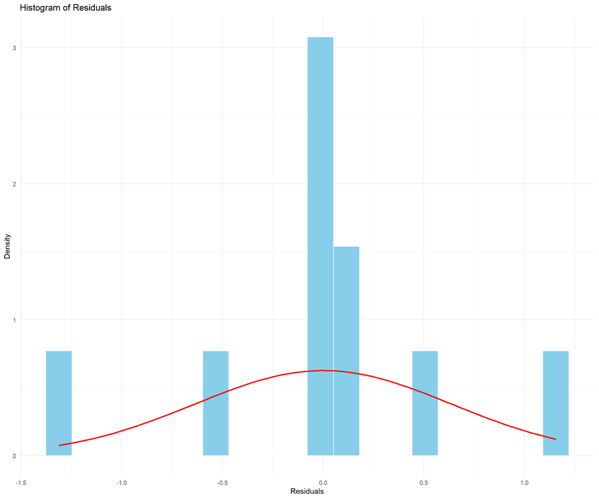

Residual Distribution Plots for Model 1

```r
ggplot(data.frame(residuals = resid(model1)), aes(x = residuals)) +
  geom_histogram(aes(y = ..density..), bins = 20, fill = "skyblue", color = "white") +
  stat_function(fun = dnorm, args = list(mean = mean(resid(model1)), sd = sd(resid(model1))), color = "red", linewidth = 1) +
  labs(title = "Histogram of Residuals", x = "Residuals", y = "Density") +
  theme_minimal()
```

```
For confidence bands, please install `qqplotr`.
```

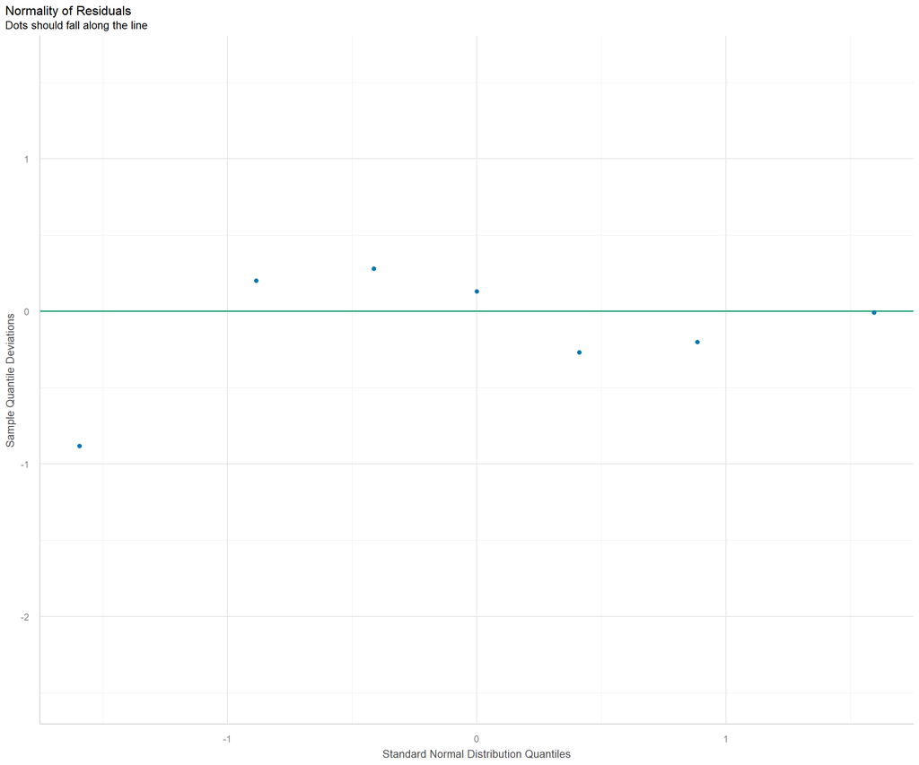

Residual Distribution Plots for Model 1

```r
plot(check_normality(model1))
```

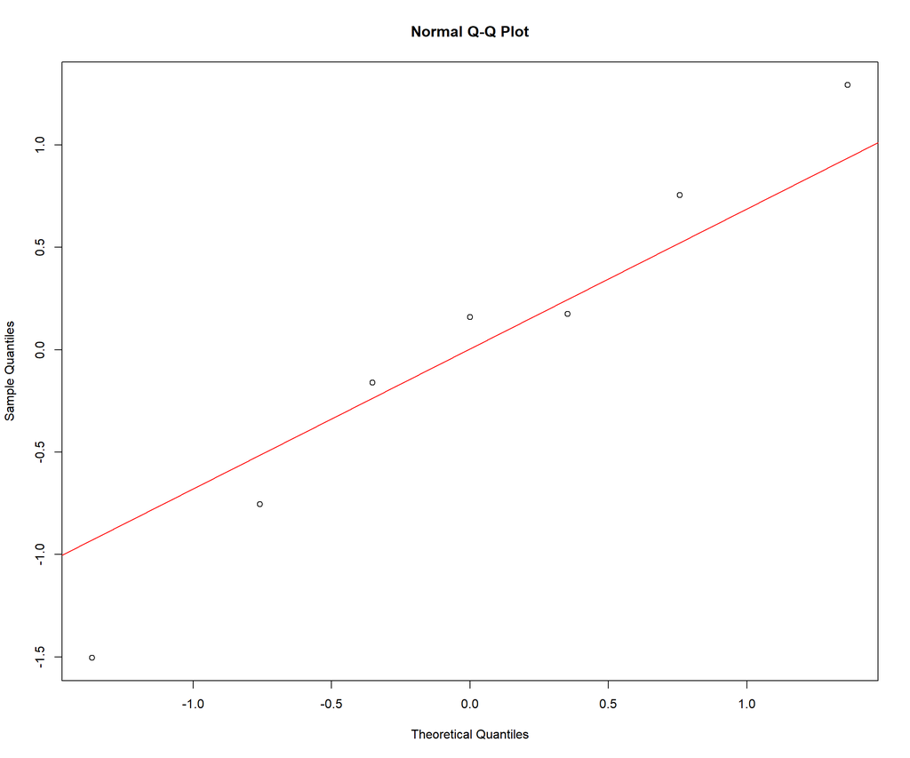

Residual Distribution Plots for Model 1

```r
qqnorm(rstandard(model1)); qqline(rstandard(model1), col = "red")
```

**Task:** Inspect the histogram and Q–Q plot. Do the residuals approximate a normal distribution?

#### Step 2c. Outliers or Influential Points

```r
performance::check_outliers(model1)
```

```
OK: No outliers detected.
- Based on the following method and threshold: cook (0.8).
- For variable: (Whole model)
```

**Task:** Note any cases flagged as outliers. What threshold is used?

#### Step 2d. Examine Residuals

```r
residuals <- resid(model1)
std_residuals <- residuals / sd(residuals)
max(std_residuals); min(std_residuals)
```

```
[1] 1.814074
```

```
[1] -2.059219
```

```r
car::outlierTest(model1)
```

[output not shown]

**Task:** Identify any standardized residuals exceeding ±3.29. How might they influence model fit?

### Step 3: Check Homoscedasticity

```r
performance::check_heteroscedasticity(model1)
```

```
OK: Error variance appears to be homoscedastic (p = 0.535).
```

**Task:** Is there evidence of unequal variance across fitted values?

### Step 4: Check Multicollinearity

```r
performance::check_collinearity(model1)
```

```
# Check for Multicollinearity

Low Correlation

     Term  VIF   VIF 95% CI adj. VIF Tolerance Tolerance 95% CI
 stressmo 4.13 [3.43, 5.04]     2.03      0.24     [0.20, 0.29]
 hourwnit 4.13 [3.43, 5.04]     2.03      0.24     [0.20, 0.29]
```

**Task:** What are the VIF and Tolerance values? Are they within acceptable limits (< 5 and > 0.2)?

### Step 6: Summary Diagnostic Plots

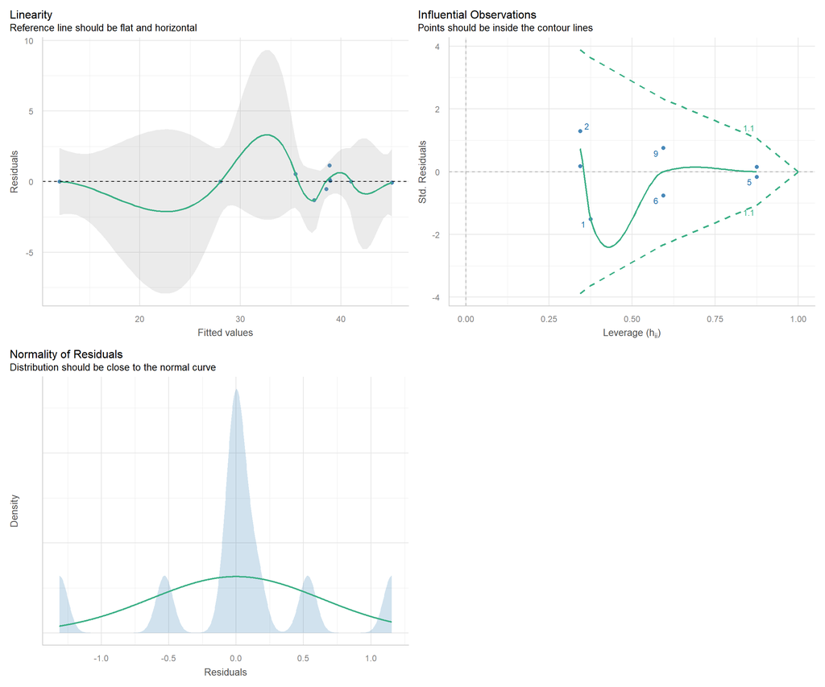

Diagnostic plots for Model 1

```r
# If using R 4.4.x use
performance::check_model(model1,
  check = c(
    "linearity",
    "homoscedasticity",
    "outliers",
    "collinearity",
    "normality"
  )
)
```

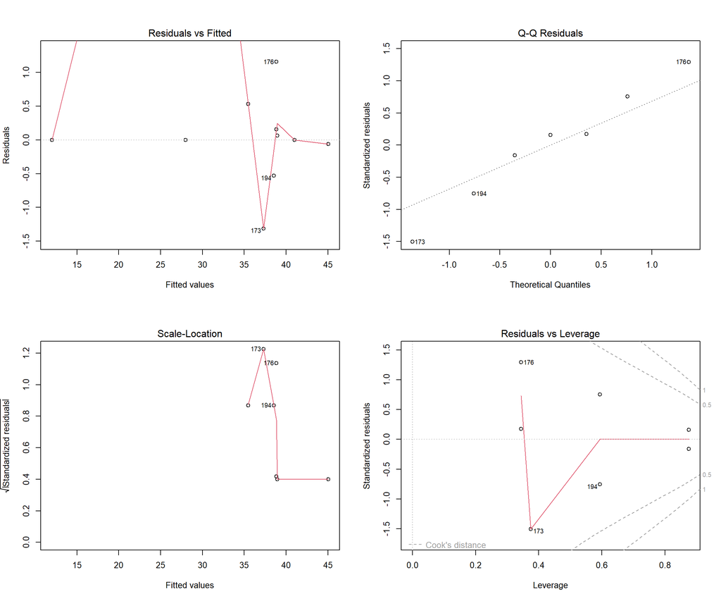

Diagnostic plots for Model 1

```r
# If using R 4.5.x use
# If using R 4.5.x Show all 4 diagnostic plots in one figure using R basic plots
par(mfrow = c(2, 2))   # 2x2 grid layout
plot(model1)            # Generates: Residuals vs Fitted, Normal Q-Q, Scale-Location, Cook’s distance
```

```r
par(mfrow = c(1, 1))    # Reset layout
```

**Task:** Review the combined diagnostics. Which assumptions are well met, and which may require attention?

### Task: Write the report

# 3. Model 2 — Add Gender as a Predictor

Now extend the model by adding `gender` as a control variable.

```r
# Ensure gender is coded as numeric (0/1) if not already
sleep$gender <- ifelse(sleep$sex == "male", 0, ifelse(sleep$sex == "female", 1, NA))

# Fit the extended model
model2 <- lm(totsas ~ stressmo + hourwnit + gender, data = sleep)
summary(model2)
```

```
Call:
lm(formula = totsas ~ stressmo + hourwnit + gender, data = sleep)

Residuals:
       173        176        181        184        186        194        197
 2.703e-02  4.865e-01  1.570e-16 -5.135e-01  4.054e-02 -6.757e-02 -4.054e-02
       204        228        246
 2.264e-16  6.757e-02  4.337e-18

Coefficients:
            Estimate Std. Error t value Pr(>|t|)
(Intercept)  36.8378     2.4330  15.141 0.004334 **
stressmo5    29.0000     0.7166  40.469 0.000610 ***
stressmo6    23.9324     0.6533  36.634 0.000744 ***
stressmo7    27.5135     0.6178  44.535 0.000504 ***
stressmo8    30.8243     0.6638  46.435 0.000463 ***
stressmo9     4.6486     1.3276   3.501 0.072773 .
hourwnit     -3.7838     0.3725 -10.157 0.009555 **
gender        1.6486     0.4712   3.499 0.072880 .
---
Signif. codes:  0 '***' 0.001 '**' 0.01 '*' 0.05 '.' 0.1 ' ' 1

Residual standard error: 0.5067 on 2 degrees of freedom
Multiple R-squared:  0.9993,    Adjusted R-squared:  0.997
F-statistic: 433.9 on 7 and 2 DF,  p-value: 0.002301
```

A second multiple linear regression model was fitted to determine whether gender further improved prediction of daytime sleepiness and fatigue when combined with perceived stress and weeknight sleep duration. The overall model was statistically significant, F(7, 2) = 433.90, p = 0.002, explaining approximately 99.9% of the variance in sleepiness (Adjusted R² = 0.997).

The fitted regression equation was:

Sleepiness (totsas) = 36.84 + 29.00 × Moderate perceived stress (level 5) + 23.93 × Moderately high perceived stress (level 6) + 27.51 × High perceived stress (level 7) + 30.82 × Very high perceived stress (level 8) + 4.65 × Extremely high perceived stress (level 9) – 3.78 × Average hours of sleep on weeknights + 1.65 × Gender (1 = female, 0 = male)

## Assess Assumptions

### Step 1: Generate Summary Statistics

```r
pastecs::stat.desc(sleep$gender, basic = FALSE)
```

```
      median         mean      SE.mean CI.mean.0.95          var      std.dev
   1.0000000    0.7000000    0.1527525    0.3455502    0.2333333    0.4830459
    coef.var
   0.6900656
```

```r
table(sleep$gender, useNA = "ifany")
```

```
0 1
3 7
```

```r
prop.table(table(sleep$gender))
```

```
  0   1
0.3 0.7
```

**Task:** Are both genders adequately represented in the dataset?

### Step 2: Residual Analysis

#### Step 2a. Normality Test

```r
performance::check_normality(model2)
```

```
OK: residuals appear as normally distributed (p = 0.389).
```

#### Step 2b. Visualize Residual Distribution

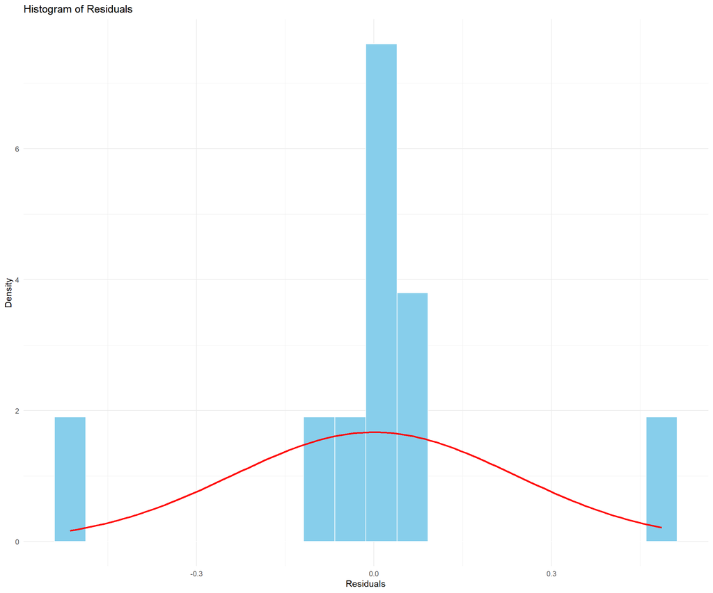

Residual Distribution Plots for Model 2

```r
ggplot(data.frame(residuals = resid(model2)), aes(x = residuals)) +
  geom_histogram(aes(y = ..density..), bins = 20, fill = "skyblue", color = "white") +
  stat_function(fun = dnorm, args = list(mean = mean(resid(model2)), sd = sd(resid(model2))), color = "red", linewidth = 1) +
  labs(title = "Histogram of Residuals", x = "Residuals", y = "Density") +
  theme_minimal()
```

```
For confidence bands, please install `qqplotr`.
```

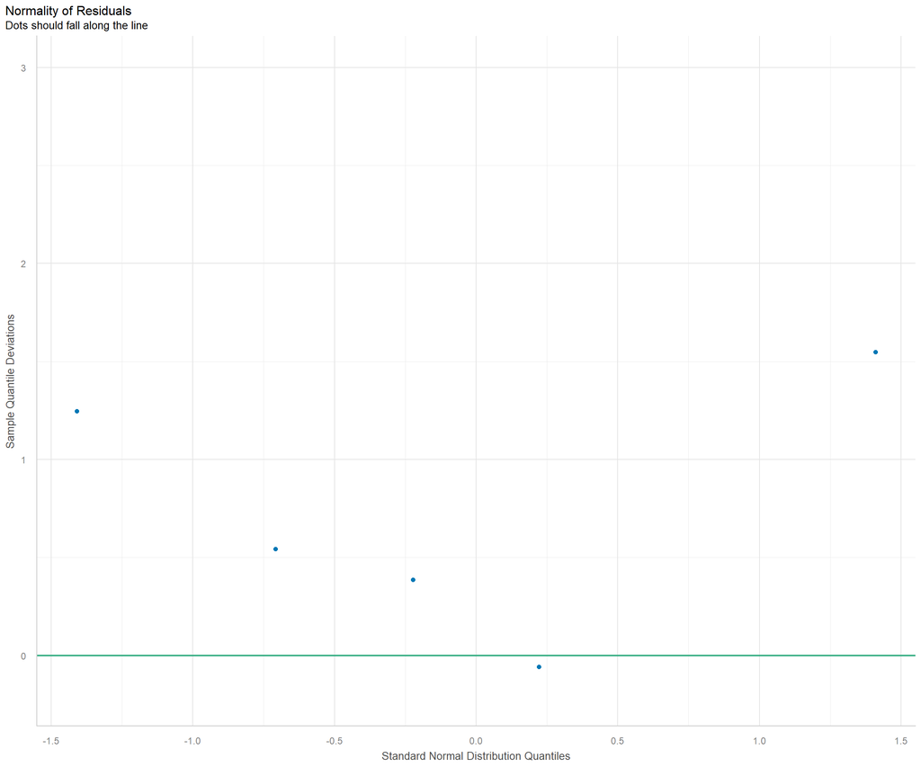

Residual Distribution Plots for Model 2

```r
plot(check_normality(model2))
```

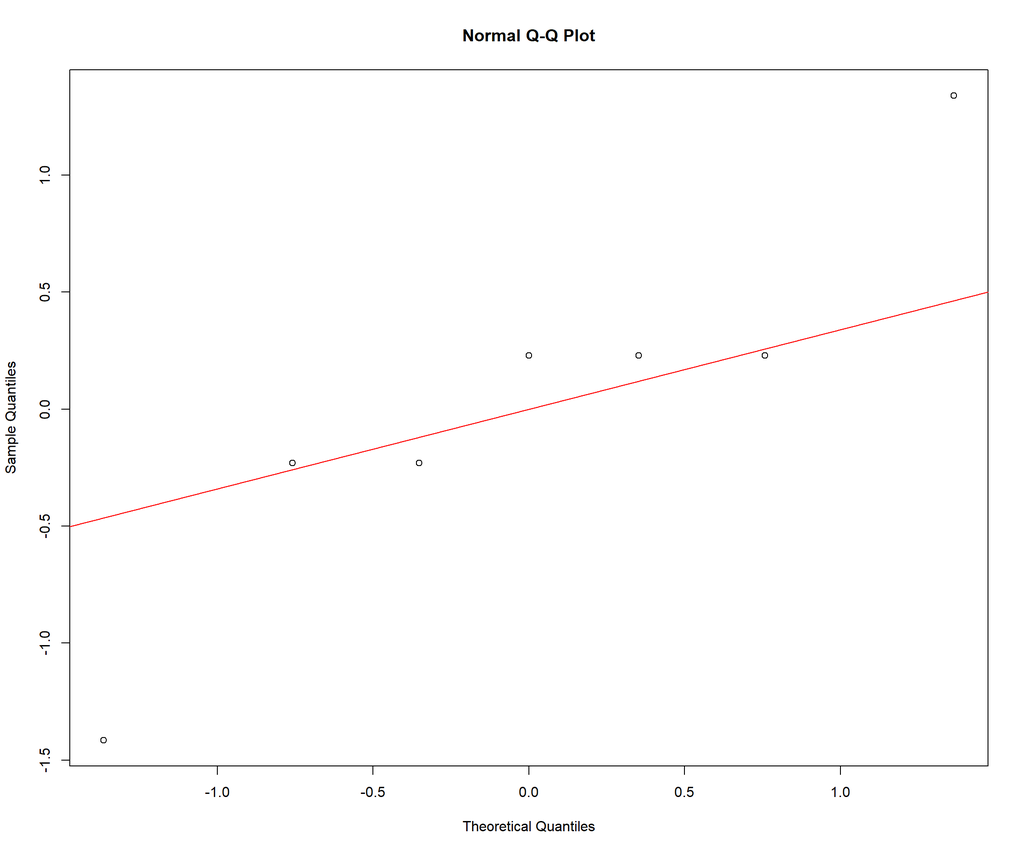

Residual Distribution Plots for Model 2

```r
qqnorm(rstandard(model2)); qqline(rstandard(model2), col = "red")
```

#### Step 2c. Outliers or Influential Points

```r
performance::check_outliers(model2)
```

```
OK: No outliers detected.
- Based on the following method and threshold: cook (0.9).
- For variable: (Whole model)
```

#### Step 2d. Examine Residuals

```r
residuals <- resid(model2)
std_residuals <- residuals / sd(residuals)
max(std_residuals); min(std_residuals)
```

```
[1] 2.036649
```

```
[1] -2.149796
```

```r
car::outlierTest(model2)
```

```
No Studentized residuals with Bonferroni p < 0.05
Largest |rstudent|:
    rstudent unadjusted p-value Bonferroni p
176 2.959182            0.20746           NA
```

### Step 3: Check Homoscedasticity

```r
performance::check_heteroscedasticity(model2)
```

```
OK: Error variance appears to be homoscedastic (p = 0.302).
```

### Step 4: Check Multicollinearity

```r
performance::check_collinearity(model2)
```

```
# Check for Multicollinearity

Low Correlation

   Term  VIF   VIF 95% CI adj. VIF Tolerance Tolerance 95% CI
 gender 1.82 [1.68, 1.97]     1.35      0.55     [0.51, 0.59]

Moderate Correlation

     Term  VIF   VIF 95% CI adj. VIF Tolerance Tolerance 95% CI
 stressmo 7.44 [6.73, 8.25]     2.73      0.13     [0.12, 0.15]
 hourwnit 5.96 [5.40, 6.59]     2.44      0.17     [0.15, 0.19]
```

### Step 5: Summary Diagnostic Plots

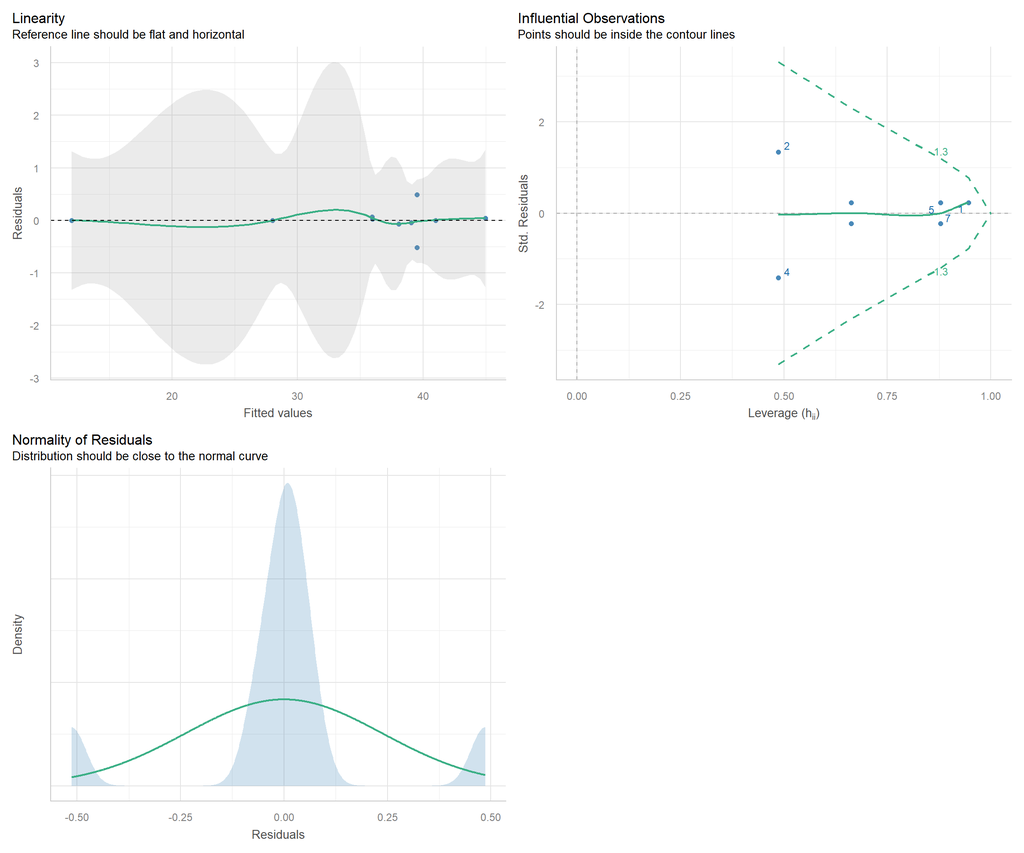

Diagnostic plots for Model 2

```r
# If using R 4.4.x use
performance::check_model(model2,
  check = c(
    "linearity",
    "homoscedasticity",
    "outliers",
    "collinearity",
    "normality"
  )
)
```

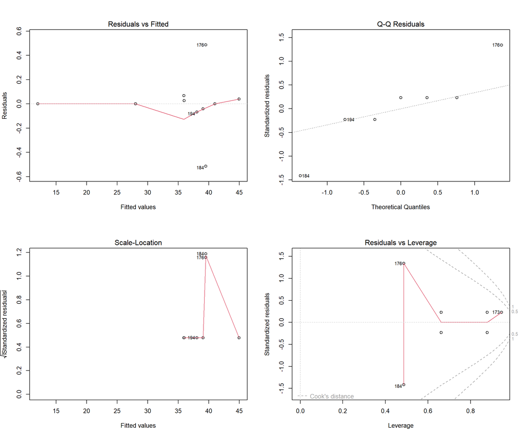

Diagnostic plots for Model 2

```r
# If using R 4.5.x use
# If using R 4.5.x Show all 4 diagnostic plots in one figure using R basic plots
par(mfrow = c(2, 2))   # 2x2 grid layout
plot(model2)            # Generates: Residuals vs Fitted, Normal Q-Q, Scale-Location, Cook’s distance
```

```r
par(mfrow = c(1, 1))    # Reset layout
```

### Task: Write the report

# Task: Reflection

1. Compare Model 1 and Model 2. Does adding gender improve the model?
2. Which assumptions are most/least well met in each model?
3. Suggest one possible next step if violations were detected (e.g., transformation, re-specification, removal of outliers).

**End of Exercise**